# Simulation_Example

Tim Toavs

2023-07-09

# Intro

Simulation is influenced by the FishScales data but is mostly controlled by random processes which allow for a wide variety of possibilities to occur.

For the analyzed simulation data, there were 8 scenarios with differing sampling regimes and underlying species richness distributions.

Sampling regimes:

- constant high (n=50)
- constant low (n=10)
- dominate high (75% n=50, 25% n=10)
- dominate low (75% n=10, 25% n=50)

Richness Distribution:

- High (mu = 75, sigma = 5)
- Low (mu=30, sigma = 5)

# Simulation

### Simulation settings

First step is to set the settings of the simulation, which involves creating a distribution of possible species richness values, setting the number of sites, setting the sampling effort, and creating a distribution of detection probabilities. For the purpose of this example I set the settings to high diversity and constant high sampling.

Note: Species richness distribution comes from calculating the observed species richness at the HUC8 level in FishScales of high sampling sites (n>50).

Note: Beta distribution for detection probabilities comes from FishScales by calculating the detection probability for each species at the HUC8 level and taking the average, then calculating the shaping parameters.

```r
mean_SR <- 75
sd_SR <- 5
site_number <- 30
sampling_effort <- 50
beta_alpha <- 0.5637479
beta_beta <- 3.471836
```

### Sites

Randomly pull a SR value for each site and create a data frame.

```r
site.df <- data.frame(cbind(
  site = seq(1, site_number, 1),
  richness = as.integer(rnorm(site_number, mean_SR, sd_SR))
))
```

### Species

Create a dataframe of species in each site that are then assigned a detection probability from the created beta distribution.

```r
temp_list <- list()

for(i in 1:site_number){
  temp_list[[i]] <- data.frame(cbind(
    site = i,
    species_num = seq(1, site.df$richness[i], 1),
    beta_detection = rbeta(site.df$richness[i], beta_alpha, beta_beta)
  ))
}

df <- bind_rows(temp_list)
```

Assign sampling effort across all sites.

```r
site.df$effort <- 50

df <- merge(df, site.df, by ="site")
```

Then, run sampling simulation where a Bernoulli trial is run for each species using the beta distribution value as the probability of success and repeated for each sampling event.

```r
sampling_sim <- list()


for(i in 1:site_number){

  temp <- df %>%
    filter(site == i)

  temp2 <- data.frame(matrix(ncol = nrow(temp), nrow = mean(temp$effort)))

  site_richness <- nrow(temp)

  for(sample in 1:site_richness){
    temp2[,sample] <- sample(c(1,0), size = temp$effort[sample], prob = c(temp$beta_detection[sample], 1-temp$beta_detection[sample]), replace = T)
  }

  sampling_sim[[i]] <- temp2

}
```

# Visualization

A look at the raw species accumulation curves.

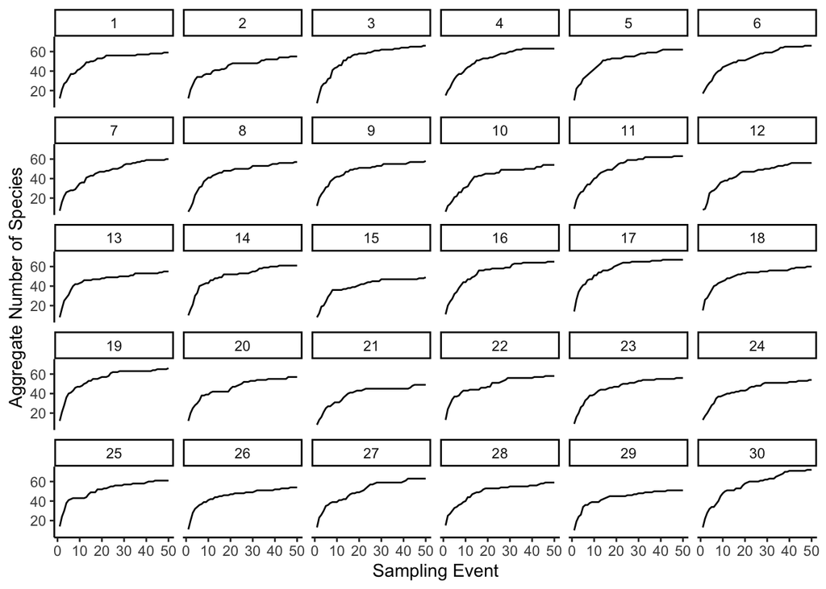

```r
ggplot(data = dat_final, aes(x=as.numeric(event_seq), y=as.numeric(agg_unique_species), group = site)) +
  geom_line() +
  facet_wrap(~site) +
  labs(x="Sampling Event", y="Aggregate Number of Species") +
  theme_classic()
```